# Python Proqramlaşdırma dili

Python dili haqqında

Python dili - müxtəlif paradiqmaları dəstəkləyən proqramlaşdırma dilidir, 1991-ci ildə Guido van Rossum tərəfindən yaradılmışdır. Python dilinin sintaksisi digər dillərə nisbətən aydın və anlaşıqlıdır.

Python tam dinamik tiplidir və avtomatik yaddaş idarəetmə xüsusiyyətinə malikdir. Perl, Ruby, Scheme, Smalltalk, və Tcl dillərinə oxşarlıq göstərir. Proqramlaşdırma fəlsəfəsi

Python müxtəlif paradiqmaları dəstəkləyən proqramlaşdırma dilidir. Obyekt yönümlü proqramlaşdırma, struktur proqramlaşdırma, funksiyonal proqramlaşdırma bunlara misal ola bilər.

Python script dili kimi veb və desktop mühitlərində geniş istifadə olunur. Böyük şirkətlər Google, Yahoo və s python dilindən geniş istifadə edirlər. Python böyük araşdırma mərkəzlərində də (məsələn: CERN kimi) geniş istifadə olunur və elmi hesablamalar üçün çoxlu kitabxanalara malikdir. Bunlara misal olaraq NumPy, SciPy və Matplotlibi göstərmək olar.

Pythonun sintaksisi öyrənmək üçün çox sadədir.

Mənbə https://az.wikipedia.org/wiki/Python </small>

Çağdaş dünyamızda data(Məlumatlar,verilənlər)ların artması ilə əlaqədər günlük statistik hesablamaları,analizləri idarə etmək məcburiyyətində qalırıq.Bu yöndə hal-hazırda şirkətlər kağız üzərində hesablamalar deyil,günümüzün aktual mövzularından olan Sünii İntelektin alt qrupu-Maşın Öyrənmə(Machine Learning) ilə həll üsullarına üstünlük verir.Sənayenin inkişafı ilə əlaqədar müxtəlif fabrik və zavodların işçi mühitini robot sənayesi ilə dəyişdirməyə çalışırlar. Və bütün bu sənayənin istifadəsi üçün təməldə proqramlaşdırma dillərinə ehtiyyac var.Hal-hazırda Python dili statistik göstəricilərdə ön sıralardadır.Günümüzdə Maşın Öyrənmə,Dərin Öyrənmə sahələrində də Python dilindən geniş istifadə olunur.Python dili Web proqramlaşdırmada(django,Flask framework),Mobil aplikasiyaların hazırlanılmasında(Kivy),Stolüstü aplikasiyaların hazırlanılmasında(PyQt5,Tkinter) ,kiçik tək panelli kompüterlər seriyası(small single-board computers- Raspberry Pi ,Asus tinker board,Nvidia Jetson Tx1,2,Jetson Nano ) sistemlərin idarə edilməsində geniş istifadə olunur.

Python proqramlaşdırma dili çeşidli mühitlərdə istifadə olunan güclü və dinamik bir dildir. Python proqramlaşdırma dili; Səlis və rahat oxumaq olur Rahat başa düşülür OOP proqramlaşdırma xüsusiyyətinə malikdir Geniş kitabxanalara malikdir. Daha az kodla çox iş görmə imkanı C++ dili ilə qarşılaşdıraq#include using namespace std; int main() { cout << "Hello World"; return 0; }Python ilə

```python
print("Hello World");
```

```
Hello World
```

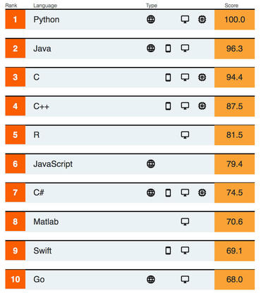

```python
 from IPython.display import Image
Image("image/ieee.jpg")
```

https://spectrum.ieee.org/computing/software/the-top-programming-languages-2019

Python dili bir çox əməliyyat sistemlərində,platformalarda çalışa bilir.(Windows,Linux/Unix,Raspberry Pi,Android,IOS,Nvidia jetson Nano) Python dili dili iki halda sistemdə çalışa bilir.Həm interaktiv həm də skript modunda.İnteraktiv modda dilin çalışması kodlarımızı test etmək üçün ideal vasitələrdən biridir. Python dilindən istifadə üçün ilk öncə dil ilə bağlı interpreter təməldə çalışdırılır.Bu interpreter olmadan Python un sistemdə çalışması qeyri mümkündür.Python skript dil olduğundan bəzi başqa dillər kimi virtual mühitdə çalışmır.Yazdığımız kodları birbaşa çalışdırıb nəticəni görə bilərik.

Python dilində kodlarımızı yazmaq üçün bizə dilin sistemə yüklənməsi və sadə mətn editoruna ehtiyacımız var.Bunun üçün Python dilini dəstəkləyən Anaconda platformasını sistemə yükləyib istifadə edəcəyik.Platform 600-dən artıq python paketini sistemə qurduğundan ehtiyyacımız olan bir çox əməliyyatları rahatlıqla tətbiq edə biləcəyik.Bundan başqa Kerneli İpython olan Jupyter notebook editorunu da sistemə yüklədiyindən kodlarımızı sürətli şəkildə sadə mühitdə test edə biləcəyik

Anaconda Platformasını yükləmək üçün https://www.anaconda.com/distribution/

## Python proqramlaşdırma dili

Günlük həyatımızda istifadə etdiyimiz söz,söz birləşmələri,ədədlər,coğrafi adlar,şərti işarələr,simvollar və sairə bütünlükdə Turinq maşınları üçün verilənlərdir(Data). Və bu dataları ifadə etmək üçün proqramlaşdırma dili turinq maşınları ilə aramızda ünsiyyət vasitəsi rolunu oynayır.Bəsit ifadələr yazaraq python dilinə ümumi giriş edək

Python dilində sözləri ifadə etmək üçün tək cüt və üçəm dırnaqdan istifadə olunur.

```python
'Python'
```

```
'Python'
```

```python
"Python"
```

```
'Python'
```

```python
"""Python"""
```

```
'Python'
```

Yuxarıdakı nümunələrdə verilən Python ifadəsidir.Hər üç halda eyni nəticəni ekranda çap etdi.Sual olunurki eyni nəticəni alırıqsa hər üç dırnaq işarəsi niyə istifadə olunur.! Aşağıdakı nümunədə bunun səbəbini anlayacaqsınız

```python
'Bakı Azərbaycan'ın paytaxtıdır.'
```

```
  File "<ipython-input-6-7d43d01661fb>", line 1
    'Bakı Azərbaycan'ın paytaxtıdır.'
                      ^
SyntaxError: invalid syntax
```

Və xəta aldıq.Cümlə daxilində apastrof istifadə etmək istədik amma mümkün olmadı.Bunun üçün ifadəmizi cüt dırnaq daxilində yazıb tək dırnaq işarəsini apastrof-əvəzedicisi kimi yazaq

```python
"Bakı Azərbaycan'ın paytaxtıdır."
```

və xətasız ekrana çap olundu.Digər yolu tərs sləş işarəsindən istifadəsidir.

```python
'Bakı Azərbaycan\'ın paytaxtıdır.' # \' -xüsusi işarəsi
```

```python
'Kursumuzun mövzusu "Python" proqramlaşdırma dilidir'
```

eynilə cüt dırnaq daxilində ifadəni qeyd etmək istədikdə

```python
"Bakı Azərbaycan"ın paytaxtıdır."
```

```python
xəta alacağıq.
```

```python
"Bakı Azərbaycan\"ın paytaxtıdır." # \" -xüsusi işarə
```

```python
'Kursumuzun mövzusu "Python" proqramlaşdırma dilidir.'
```

və ya

```python
"""Kursumuzun mövzusu "Python" proqramlaşdırma dilidir"""
```

ədədləri(varlıqların miqdar və say xarakteristikası üçün istifadə olunan anlayışdır) ifadə etmək üçün isə birbaşa yaza bilərik

```python
24
```

```python
12
```

```python
-23
```

```python
12.56
```

işarələri ifadə etmək üçün isə dırnaq işarələrindən istifadə olunur

```python
'!'
```

```python
'&'
```

```python
'-'
```

```python
*
```

Birbaşa yazsaq xəta alacağıq

Yuxarıda qeyd etdiyimiz ifadələr sadəcə ekrana çap etmək üçündür.Halbuki biz proqramlaşdırma dili ilə bir çox əməliyyatları yerinə yetirmək istəyirik və bu verilənləri istifadə etmək qeyri mümkündür.Bunun üçün alternativ olaraq python dilində dəyişənlər mövzusu var.Dəyişənlər nədir gəlin ətraflı baxaq

# Dəyişənlər (Variables)

Dəyişənləri sadə formada başa düşmək üçün; Əlimizdə 100 sayda mobil nömrə var və biz bu nömrələri birbaşa telefonun yaddaş kitabçasına təbiki qeyd etmirik.Hər bir mobil nömrə bir şəxsə məxsus olduğundan,mənsub olduğu şəxsin adını qeyd edib daha sonra yaddaşda saxlayırıq.Bu ən əlverişli üsullardan biridir.Eynilə dəyişənlər də əlimizdəki veriləni(data) müvəqqəti yaddaşda saxlamağı üçün bizim köməyimizə çatır.Kodlarımız daxilində ən başda qeyd etdiyimiz dəyişəni daha sonra istifadə etmə ehtiyyacımız olduğundan hər dəfə başa dönüb dəyişənin dəyərinə baxmaqdansa birbaşa dəyişənə qeyd edib kodlarımızın istənilən yerindən çağıra bilərik. dəyişənlər əsasən iki təsnifatda qlobal və lokal olaraq ifadə edilir.Bunların nə olduğunu irəliləyən dərslərdə ətraflı izah edəcəyəm.Sadə şəkildə formulumuz "dəyişənin_adı = dəyişənin_dəyəri"formasındadır.Qeyd edimki burda bərabərlik - mənimsətmə operatoru adlanır.Dəyişənlərlə bağlı bir neçə şərtlər var</font>

1.Dəyişənlər ədəd ilə başlaya bilməz 2.Dəyişənlər Python dilinə məxsus açar sözlərdən ibarət ola bilməz. 3.Dəyişənlər söz birləşməsindən təşkil olunubsa,aralarında boşluq istifadə edilə bilməz. 4.Dəyişənlər durğu işarələri( ayırıcı işarələr,fərqləndirici işarələr.) ilə başlaya bilməz. 5.Dəyişənlər, böyük və kiçik hərflə başlamsı eyni dəyişəni ifadə etmir 1.Dəyişənlər sadəcə sözlərdən və alt-tire işarəsi ilə başlaya bilər. 2.Dəyişənlər qısa və dəyişənin dəyərinə uyğun yazmaq məqsədəuyğundur. 3.Dəyişənləri proqram boyu çağırmadığınız müddətcə çalışmaz. 4.Dəyişənlər Azərbaycan dili əlifbası ilə yazıla bilər.

```python
12user = "Admin";
```

Python dilinə məxsus açar sözlər.Aşağıda açar sözləri tək-tək yazmaq yerinə birbaşa python daxilindən çağıraq.yazacağım kodları diqqətə almayın,çünki modullar bəhsində ətraflı öyrənəcəyik

```python
import keyword
```

```python
print(keyword.kwlist)
```

```python
print("Açar sözlərin sayı : ",len(keyword.kwlist))
```

Dəyişənlərə açar sözləri vermək olmaz.əks halda xəta ilə üzləşəcəksiniz

```python
from = "Python";
print(from)
```

```python
user name = "Admin";
```

```python
)lang = "Python";
```

```python
_user = "Admin";
```

```python
_user
```

```
'Admin'
```

```python
import keyword
```

```python
qadağan_olunmuş_sözlər = keyword.kwlist
```

```python
print(qadağan_olunmuş_sözlər)
```

```
['False', 'None', 'True', 'and', 'as', 'assert', 'async', 'await', 'break', 'class', 'continue', 'def', 'del', 'elif', 'else', 'except', 'finally', 'for', 'from', 'global', 'if', 'import', 'in', 'is', 'lambda', 'nonlocal', 'not', 'or', 'pass', 'raise', 'return', 'try', 'while', 'with', 'yield']
```

```python
var1 = 12;
```

var1 - dəyişənini çağırmadığınız müddətcə çalışmaz.

```python
var1
```

```
12
```

Dəyişənlərə birdən çox dəyər mənimsətmə

```python
var1,var2 = "Python","Java"
```

```python
var1
```

```
'Python'
```

```python
var2
```

```
'Java'
```

```python
a = "Machine learning";
b = "Deep Learning";
b=a
```

```python
a
```

```
'Machine learning'
```

```python
b
```

```
'Machine learning'
```

```python
a,b = "Python","C++"
```

```python
b,a
```

```
('C++', 'Python')
```

```python
b
```

```
'C++'
```

```python
a
```

```
'Python'
```

```python
Ad = "Eldar"
ad = "Musa"
```

Yuxarıda qeyd olunan iki dəyişən bir-birindən fərqli dəyişənlərdir.

```python
Ad
```

```
'Eldar'
```

```python
ad
```

```
'Musa'
```

# Operator və Operandlar

## Riyazi Operatorlar(Arithmetic operators)

Orta məktəbdə keçdiyimiz qaydada "Python" dilində də riyazi operatorlar dəyişməz olaraq qalır.Bunlar aşağıdakılardır; 1. + toplama 2. - çıxma 3. * vurma(hasil) 4. / bölmə 5. % Qalıqlı bölmə 6. // Qalıqsız bölmə 7. ** Qüvvət Yuxarıda göstərilənlər operator və bu əməliyyatları üzərinə tətbiq etdiyimiz ifadələr operandlar adlanır.Asta-asta ədəd və sözlər üzərinə tətbiq edək.

```python
var1 = 12;
var2 = 6;
result  = var1+var2;
```

```python
result
```

```
18
```

iki dəyişən (var1,var2) qeyd edib ədəd mənimsətdik.Daha sonra result dəyişəninə toplama əməlindən istifadə edərək digər iki dəyişəni əlavə etdik.Ekrana 18 - cavabı çap olundu.

```python
num1 = -3;
num2 = -1;
num1-num2
```

```
-2
```

```python
a = 19;
b = 67;
cavab = a-b;
```

```python
cavab
```

```
-48
```

```python
a = 12;
b = 2;
cavab = a*b
```

```python
cavab
```

```
24
```

```python
var1,var2 = 3,41;
```

```python
var1
```

```
3
```

```python
var2
```

```
41
```

```python
var1*var2
```

```
123
```

```python
a,b = 67,23
```

```python
cavab = a/b
```

```python
cavab
```

```
2.9130434782608696
```

```python
a = 1;
b = 0;
cavab = a/b
```

```
---------------------------------------------------------------------------
ZeroDivisionError                         Traceback (most recent call last)
<ipython-input-41-fc599dace807> in <module>
      1 a = 1;
      2 b = 0;
----> 3 cavab = a/b

ZeroDivisionError: division by zero
```

```python
a = 40;
b = 18;
a/b
```

Əgər cavabı tam ədəd almaq istəsək;

```python
a = 40;
b = 18;
a//b
```

kimi yazacağıq.% - qalıqlı bölmə işarəsi bir ədədin digər ədədə bölünməsindən qalan qalığı bizə göstərir.

```python
a = 12;
b = 5;
cavab = a%b
```

```python
cavab
```

12- ədədini 5-ə böldükdə qalan qalıq ikidir.5 ədədi 12-ədədində 2 dəfə qalan qalıq 2-dir

```python
a = 2;
b = 3;
qüvvət = a**b
```

```python
qüvvət
```

```python
num1,num2 = 3,4
num1**num2
```

Qeyd olunan riyazi operatorların bəzilərindən sözlər üzərinə də tətbiq edə bilər

```python
a = "Python"
b = "proqramlaşdırma dili"
```

```python
a+b
```

```python
a + " " + b
```

```python
a = "w"
b = 3
a*b
```

```python
a="#"*12
b="*"*14
```

```python
a,b
```

```python
a
```

```python
b
```

```python
a = 2
b = "Deep Learning"
b**a
```

# print() funksiyası

Php dilində echo,C++ dilində cout olduğu kimi,Python dilində də ifadələri ekrana çap etmək üçün print() funksiyasından istifadə olunur.Bura qədər yazdığımız kodlar jupyter-notebook daxilində olduğundan biz kodlarımızı python-skript formasında çalışdırsaq ekranda heç bir ifadə görünməyəcəkdir. Jupyter notebook kerneli ipython olduğundan print() funksiyası istifadə etmədən belə dəyişənləri çağırdıqda ekrana çap edilir.Bu python shell -ə xas xüsusiyyətdir.Siz həmçinin bura qədər yazılan ifadələri terminaldan python - u çağırıb test edə bilərsiniz. Bütün bu bəhslərdə irəlilədikcə biz kodlarımızı mətn editorlarında yazacağımız üçün gəlin ifadələrimizi bir fayla qeyd edib çalışdıraq.

```python
print()
```

```python
a = 10;
b = 12;
cavab = a**b
print(cavab)
```

print() funksiyası daxilində birdən çox dəyişən ala bilir

```python
print("Python","C++","Java")
```

```python
print('G','F','G');
```

yuxarıdakı ifadələrdə bir neçə söz qeyd etdik ekran çapında isə aralarında boşluq olaraq çap olundu.Bunun səbəbi print() - funksiyasının ala bildiyi sep(separator-ayırıcı) parametrindən qaynaqlanır.sep - parametri qeyd olunmasa belə funksiya daxilində parametri istifadə edir.default olaraq boşluq ilə ifadələri çap edir.print(arg1,arg2,sep=' ')

```python
a,b = "Vahid","Mahmud"
```

```python
print(a,b)
```

```python
print(a,b,sep=",")
```

və yuxarıdakı nümunədə sep-parametrindən istifadə etdik.parametr default olaraq sep=" " daxilində boşluq arqumenti ilə qeyd olunduğundan print() funksiyası daxilində yazmasaq belə qeyd olunur.Biz ifadələrimiz arasında vergül işarəsini əlavə etmək istədikdə isə sep-parametrinə vergül argumentini əlavə etdik.

```python
a = "Machine"
b = "learning"
print(a,b)
```

```python
print(a,b,sep = "-")
```

Qeyd edimki sep parametri argument kimi ədədləri qəbul etmir.

```python
a = "Bir";
b = "Iki";
print(a,b,sep = 1)
```

"sep must be None or a string, not int " və xətada deyildiyi kimi sep parametri sətir tipi verilən olmalıdır.Yəni dırnaq daxilində qeyd etməlisiniz.Və print() funksiyasına da ümumi giriş etdikdən sonra əsas mövzumuz olan verilənlərin tipləri(Data Types) mövzusuna keçid edək.

# Verilənlərin tipləri(Data types)

```python
 from IPython.display import Image
Image("image/datatypes.png")
```

[output not shown]

# Tam Ədəd tipi (İnteger)

Tam ədəd tipi orta məktəbdə keçdiyimiz qaydada dəyişməz olaraq qalır.Bildiyimiz 2,3,4,-4,-5,0,999,-12 kimi ədədlər tam ədəd sayılır.Python shell-i biz hesablayıcı maşın kimi istifadə edə bilərik

```python
3+4
```

```python
1-10
```

```python
3+6
```

```python
3*4
```

```python
5**2
```

Bu ədədləri dəyişənlərlə qeyd etsək

```python
a = 3;
b = 2;
cavab = a*b
print(cavab)
```

```python
var1 = 12;
var2 = 4;
print("Cavab :",var1/var2)
```

Yuxarıda bir neçə dəyişənə tam ədəd dəyəri mənimsətdik və Python hesablama əməliyatın uğurla yerinə yetirdi.Bəs biz bir dəyişənin tipini necə sorğuya çəkək!Bunun üçün Python dili daxilində type() -funksiyası mövcuddur.Bu funksiyadan istifadə edərək verilənin tipini müəyyən edək

```python
a = 12;
type(a)
```

```python
type(-34)
```

```python
type(0)
```

```python
num1 = -13;
print(type(num1))
```

Və type() - funksiyası vasitəsilə verilənlərin tipini sorğuya çəkdik.

```python
a = 12;
b = 6;
result = a*b
print("Cavab : ",result,type(result))
```

```python
var1 = -9;
var2 = -9;
cavab = -(var1+var2);
print("Cavab:",cavab,type(cavab))
```

```python
a = 49;
b = 12;
print("Cavab:",a%b,type(a%b))
```

```python
ədəd1 = 4;
ədəd2 = 3;
cavab = ədəd2**ədəd1
```

```python
print("Cavab:",cavab)
```

```python
print(type(cavab))
```

```python
num1 = 6;
num2 = 4;
result = num1/num2
```

```python
print(result)
```

```python
print(type(result))
```

Yuxarıdakı kod nümunəsində alınan cavabın tipini soruşduqda bizə float tipində olduğunu göstərdi.Və bunu yazmaqda məqsədim integer(tam ədəd) tipini artıq öyrəndiyimiz üçün növbəti ədəd tipi,float(həqiqi ədədlər)-həqiqi ədəd tipinə keçid etməkdir

# Həqiqi ədəd tipi (Float)

Əvvəlki bəhslərdə tam ədəd tipini öyrəndik.Bu bəhsdə həqiqi ədəd tipinə keçid edirik..Dilimizə həqiqi ədəd kimi tərcümə edilir.Həqiqi ədədlər tam ədədin həqiqi dəyərini göstərir. Bank sektorlarında,kriptovalyuta ən kiçik pul hesablamalarının aparılmasında geniş istifadə olunur.Ümumiyyətlə bu ədəd tipi bizə dəyərin həqiqi qiymətini göstərir.Nümunələrə nəzər yetirəka = 12.0 həqiqi ədəd tipidir.Bunun əyani görmək üçün type() funksiyasından istifadə edəcəyik

```python
a = 12.0;
print(type(a))
```

```python
var1 = 1.5;
var2 = 2.1;
var3 = 0.99;
var4 = 24;
hesab = ((var1 - var2)-var4/var3);
print(hesab)
```

```python
print(type(hesab))
```

```python
a = 7.1;
b = 1.4;
c = a/b;
```

```python
print(c)
```

```python
num = 10;
print(num*2)
```

```python
radius = 5;
pi = 3.14;
S = pi * radius**2
```

```python
print(S)
```

```python
print(type(S))
```

Bundan əlavə digər metodlarla da həqiqi ədədləri ifadə etmək olar

```python
a = .5
```

```python
a
```

a - dəyişənin dəyəri 0.5 olaraq qeyd olundu

# e - işarəsi ilə

```python
a = 42e3
```

```python
type(a)
```

```python
a
```

e - işarəsi 10 rəqəmini ifadə edib,hesablamalarda böyük və kiçik ədədləri ifadə etmək üçün istifadə olunur.

```python
import math
```

```python
math.e
```

Sabit qiyməti olan e - ifadəsi bizim məhz danışdığımız e-ifadəsindən tamamilə fərqlidir.Təkrar olaraq istifadə etdiyimiz e-işarəsi sadəcə böyük və kiçik sayları ifadə etmək üçün istifadə olunurYuxarıdakı ifadədə (42e3), 42 ədədindən sonra 3-sıfırın gəlməsinə işarə edir

```python
num1 = 2.3e2
```

```python
print(num1)
```

```python
print(type(num1))
```

```python
num2 = 2.4e+6
```

```python
num2
```

```python
num3 = 2.4e-4
```

```python
print(num3)
```

# Qarışıq ədəd tipi (Complex)

```python
x = 3+4j
```

```python
y=x-4j
```

```python
print(type(y))
```

Yuxarıdakı formulda 3 -həqiqi hissə(tam ədəd) 4-isə xəyali hissədir.

```python
y=x-4j
```

kimi ifadə etsək

```python
print(y)
```

sadəcə əlimizdə həqiqi hissə 3 ədədi -qalacaq.

# Təyinat Operatorları (Assignment Operators)

Bura qədər tam və həqiqi ədəd tiplərini öyrəndik.Və bu ədəd tiplərinə riyazi operatorları təqdim edərək nəticələrini ekranda çap etdik.Riyazi operatorlardan başqa python dilində Təyinat operatorları da mövcuddur.(Python Assignment Operators)

```python
 from IPython.display import Image
Image("image/operators.png")
```

[output not shown]

= -mənimsətmə operatoru Bu operatordan biz nümunələrdə dəfələrlə istifadə etdik.Billirikki dəyişənlərə dəyər əlavə etmək üçün mənimsətmə(=) operatorundan istifadə edirikvar = "Bakı" - burda var dəyişənin adı, = - mənimsətmə operatoru,"Bakı" - isə dəyişənin dəyəridir

```python
var = "Bakı"
```

```python
print(var)
```

+= ; -= operatorları

```python
a = 12.4;
a = a+1
```

```python
print(a)
```

ifadəsinin yerinə

```python
a = 12.4;
a +=1
print(a)
```

kimi də yaza bilərik

```python
a = 0
a+=1
```

```python
print(a)
```

```python
a+=1
```

```python
print(a)
```

```python
a+=1
```

```python
print(a)
```

```python
a = 89;
a = a-1
```

```python
print(a)
```

```python
a = 89;
a -=1;
print(a)
```

```python
num = 10;
num -=2;
print("Iki vahid azalma : ",num)
```

```python
x = 10;
x -=3;
print("Üç vahid azalma : ",x)
```

*= ; /= operatorlarıBu operatorlar vasitəsilə vurma,bölmə əməliyyatlarını yerinə yetirə bilərik

```python
a = 5;
a *=a
print(a)
```

```python
x = 3
x*=2
print(x)
```

```python
x = 8;
x /=3
```

```python
print(x)
```

```python
var = 38;
var /= 9
```

```python
print(var)
```

```python
var = 38;
var = var/9
```

```python
print(var)
```

%= modul operatoru

```python
a = 12;
b = 5;
print("12 nin 5-ə bölünməsindən qalan qalıq :",a%b)
```

```python
a = 12;
a %=5
```

```python
print("Qalan qalıq : ",a)
```

//= operatoru

```python
x = 45
y = 19
```

```python
print(x/y)
```

```python
print(x//y)
```

```python
x = 45
x //=19
print(x)
```

**= qüvvət operatoru

```python
num1 = 6;
num2 = 2;
print("Cavab :",num1**num2)
```

```python
num1 = 6;
num1 **=2;
print("Qüvvətə yüksəltmə :",num1)
```

# Python müqayisə operatorları (Python Comparison Operators)

Biz iki ifadəni (ədəd,sətir tipi və s) böyük kiçik,xarakter sayına görə müqayisə edə bilərik.Bunun üçün Python dilində müqayisə operatorları mövcuddur.Müqayisə nəticəsində bizə True və ya False ifadələrini verir== iki mənimsətmə operatoru bərabərlik(Equal) müqayisə operatoru adlanır

```python
a = 4;
b = 3;
print(a==b)
```

Yuxarıdakı ifadədə iki tam ədədi müqayisə etdik və False ifadəsini aldıq.Təbiki 4 ilə 3 ədədi bir birinə bərabər deyil.Və ya

```python
a = 4;
b = 4;
print(a==b)
```

True ifadəsini alarıq.

```python
a = 4;
b = 4;
c =3
print(a==b==c)
```

Əgər ifadələrdən ən az biri müqayisə olunurkən bərabərliyi ödəmirsə,False -cavabını alacağıq

!= bərabər deyil operatoru (Not equal)

```python
x = 10
y = 11
print(x != y)
```

```python
x = 10
y = 10
print(x!=y)
```

```python
x = 10
y = 11
z = 12
print(x!=z !=y)
```

Hər üç ifadəni qarşılaşdırdıq və bərabər olmadığı üçün True cavabını aldıq

```python
x = 10
y = 10
z = 11
print(x!=z!=y)
```

Yuxarıdakı ifadə də isə x və y dəyişəninin dəyəri bərabər olsada biz True ifadəsini aldıq.Belə nəticəyə gəlirikki əgər dəyişənin dəyərləri arasında ən az iki ifadə bir-birinə bərabər deyilsə nəticə olaraq True - cavabını alacağıq

> Böyükdür operatoru (Greater than)

```python
a = 8
b = 12
print(a>b)
```

```python
a = 8
b = 12
print(b>a,"\n",b,"i",a,"-dən böyükdür")
```

< Kiçikdir operatoru (Less than)

```python
x = 4
y = 7
print(x<y)
```

```python
x = 4
y = 6
z = 8
```

```python
print(x<y<z)
```

>= Böyük bərabərdir (Greater than or equal to)

```python
Böyükdür və ya böyük bərabərdir.
```

```python
a = 11
b = 13
```

```python
print(a>=b)
```

```python
print(b>=a)
```

sol operandın sağ operanddan böyük və ya bərabər vəziyyətində True cavabını verir

```python
a=b=11;
print(a>=b)
```

Bu vəziyyətdə isə a b-yə bərabər olduğu üçün True -cavabını aldıq

<= Kiçik bərabərdir (Less than or equal to)Kiçikdir və ya kiçik bərabərdir.

```python
x = 4;
y = 3;
print(x<=y)
```

```python
print(y<=x)
```

# Sətir tipi verilənlər (String)

Növbəti verilən tipi-sətir tipi verilənlərdir.Əvvəlki dərslərimizdə bu verilən tipinə dair nümunələr vermişdik.Dərsin ilk başlanğıcı olduğu üçün ilk başda data tiplərindən söhbət açmaq doğru olmazdı.Bunun əvəzinə verilənlər olaraq ekrana çap etdik.Sətir tipi verilənlər tək cüt və üçəm dırnaq daxilində ifadə olunur.Sətir tipi verilənlər - simbollardan təşkil olunmuşdur.Məsələn ad = "Vüsalə" dəyişəni sətir tipi veriləndir.(Alternativ üsulu type() -funksiyası ilə sorğuya çəkməkdir).İfadə daxilində hər bir hərf bir simbolu təmsil etdiyindən bütöv hərf toplusu bizə,Vüsalə ifadəsini göstərir. Sətir tipi verilənlərin dəyəri dəyişdirmək mümkün deyil.

```python
ad1 = 'Vüsalə';
ad2 = "Eldar";
ad3 = """Aysel"""
```

```python
print(type(ad1))
```

```python
print(ad1,ad2,ad3)
```

```python
print(ad1,ad2,ad3,sep = ",")
```

```python
a = "Machine"
b = "Learning"
```

```python
print(a,b)
```

```python
a = "Data";
b = "Science"
```

```python
print(a,b,sep = "-")
```

Daha öncə keçdiyimiz riyazi operatorların bəzilərindən sətir tipi verilənlər üzərində istifadə edə bilərik

```python
a = "Python"
b = "Proqramlaşdırma dili"
```

```python
print(a+b)
```

Nümunədə iki ifadə arasındakı boşluğu yerləşdirmək üçün bir neçə üsul mövcuddur.Öncə də qeyd etdiyim kimi sətir tipi verilənlər dırnaq daxilində simbollardan(characters-xarakterlər)təşkil olunduğu üçün durğu işarələri və boşluq da bu ifadələrimizə aiddir.

```python
a = "Python"
b = "Proqramlaşdırma dili"
```

```python
print(a+" "+b)
```

```python
a = "Matplotlib";
b = "Scipy";
c = "Opencv";
```

```python
print(a+" "+b+" "+c)
```

```python
print(a,b,c,sep = ",")
```

```python
print("12"*2)
```

Yuxarıdakı nümunədə verilənin biri sətir(string) tipi,digəri isə tam(integer) ədəd tipindədir.Və vurma əməliyyatını yerinə yetirdikdə,nəticə olaraq 1212 ifadəsi ekrana çap olundu.Biz bilirikki riyazi əməliyyatları yalnız ədədlər üzərində həyata keçirdiyimiz üçün sətir tipi verilənlər üçün bu doğru nəticəni verməyəcək.Sadəcə olaraq vurma əməliyyatında sətir tipi 12-ədədini iki dəfə təkrarladı. Eynilə toplama əməliyyatında da

```python
a = "12";
b = "12";
c = a+b
print(c)
```

kimi yazsaq 24 deyil 1212 cavabını alacağıq.tipini soruşduqda isə

```python
print(type(c))
```

sətir tipi verilən olduğuna bir daha əmin olduq.Misal olaraq ###### - 6 ədəd işarəsindən istifadə etsək

```python
print("#","#","#","#","#","#",sep="")
```

yerinə

```python
print("#"*6)
```

kimi yazsaq daha məqsədəuğundur

```python
ad = "Ramin";
dost = "Namiq";
print(ad,dost,"in","dostudur.")
```

ifadəsində in şəkilçsi ayrı yazıldı.Əvvəlki nümunələrdən bilirikki,toplama işarəsindən istifadə etdikdə

```python
ad = "Ramin";
dost = "Namiq";
print(ad,dost+"in","dostudur.")
```

istədiyimiz nəticəni əldə edərik

```python
a=b=c="Eldar"
```

```python
a
```

```python
b
```

```python
c
```

```python
a="Namiq"
```

```python
a
```

```python
b
```

```python
c
```

```python
b,c = "Vüsal","Xəyal"
```

```python
print(b)
```

```python
print(c)
```

```python
b,c=c,b
```

```python
print(b)
```

```python
print(c)
```

eyniadlı fərqli dəyişənlər

```python
name = "User";
id(name)
```

```python
name = name+"name"
id(name)
```

```python
name
```

```python
print("""
Ad      : Xəyalə
Soyad   : Məhərrəmova
Mob     : +20111111
Email   :xmaharramova@example.com



""")
```

```python
məlumat = """
Ad      : Xəyalə
Soyad   : Məhərrəmova
Mob     : +20111111
Email   :xmaharramova@example.com



"""
```

```python
print(məlumat)
```

```python
a = "12";
b = 3;
c = 2.6;
d = (b+c)
```

```python
print(d+a)
```

TypeError: unsupported operand type(s) for +: 'float' and 'str' və xəta aldıq.Çünki biri sətir tipi verilən digəri həqiqi ədəd tipindədir.Toplamaq qeyri mümkündür.

```python
a = "Namiq"
b = "Eldar"
c = "Nihad"
```

```python
print(a)
print(b)
print(c)
```

Hər üç sətir tipi veriləni ekrana alt-alta çap etmək üçün 3 ədəd print() funksiyasından istifadə etdik.Amma Python dilində bunun alternativ yolu daha var.Və ardıcıllıqlardan qaçış (Escape Sequences) işarələrini öyrənək

# Escape Sequences

\n işarəsi

```python
print("Eldar","Namiq")
```

alt-alta yazmaq üçün

```python
print("Eldar","\nNamiq")
```

kimi yazırıqnew line - yeni sətir mənasını ifadə edir.Eynilə yuxarıdakı üç dəyişəni

```python
a = "Namiq"
b = "Eldar"
c = "Nihad"
```

yazıb

```python
print(a+"\n",b+"\n",c)
```

\ -tərs sləş işarəsi (Backslash and newline ignored)

```python
print("Python\
 programming language")
```

```python
print("Python\
 Artificial Intelligense\
 Machine Learning\
 Deep Learning")
```

\' Apastrof işarəsi (Single quote ('))

```python
information = 'Bakı,Azərbaycan\'ın paytaxtıdır'
```

```python
print(information)
```

```python
print('\'')
```

\t - işarəsi (Horizontal Tab (TAB))

horizontal istiqamətdə bir tab düyməsi qədər ifadəni irəli atır.

```python
a = "Salam Azərbaycan"
```

```python
a
```

```python
a = "Salam\tAzərbaycan"
```

```python
print(a)
```

```python
a = "Computing\nVision"
```

```python
print(a)
```

```python
print("Name : Vusal\
    Surname : Mammadov\
    Email   : vmammadov@example.com\
    Mob     : +33332332323")
```

```python
print("""
Name    : Vusal
Surname : Mammadov
Email   : vmammadov@example.com
Mob     : +33332332323


""")
```

```python
a = "wwww"
b = "python"
c = "org"
```

```python
print(a,b,c,sep=".")
```

```python
print(type(a))
```

```python
a = "Python"
print(a*3)
```

```python
a = "#"
print(a*8)
```

```python
a = """
#--------------------[x][-]
#                         #
# Proqrama xoş gəmisiniz  #
#      versiya : 0.1      #
#                         #
#-------------------------#

"""
```

```python
print(a)
```

Sətir tipi verilənlər xarakterlərdən ibarət olduğu üçün python dilində len() - funksiyası vasitəsilə xarakterlərin sayını müəyyən edə bilərik.

# len() - funksiyası

Funksiya daxilində bir arqument alır.Funksiyanı sətir tipi verilənlərə tətbiq edək

```python
len("Python")
```

Python sətir tipi verilənlərin simvol sayı, normal qaydada birdən başlayaraq sayılır.Yəni

```python
print("""

    P y t o h n

    1 2 3 4 5 6


""")
```

```python
a = "Machine Learning"
```

```python
len(a)
```

```python
print("""

     M a c h i n e   L e  a  r  n  i  n  g
     1 2 3 4 5 6 7 8 9 10 11 12 13 14 15 16



""")
```

Yuxarıdakı ifadədə 16 sayda xarakter olduğu məlum oldu.Qeyd edimki boşluqlar da nəzərə alınır.Hər birini, bir simbol təşkil etdiyindən sətir tipi verilənlər xarakterləri təşkil edir.

```python
var = "Monthy Python";
print(len(var))
```

```python
a = "!@#$%^&*"
```

```python
print(len(a))
```

Yuxarıdakı nümunədə gördüyünüz kimi işarələri də qeyd etsəkdə,sətir tipi verilən olduğu üçün len() funksiyası vasitəsilə sayını təyin edə bildiklen() - funksiyasını sadəcə olaraq ədəd tiplərinə tətbiq edə bilmirik

```python
a = 12345
print(len(a))
```

TypeError: object of type 'int' has no len() və xəta aldıq.Bunun alternativ yolu Python dilində tip çevirmələri ilə reallaşır

# Pythonda tip çevirmələri (Type Conversion in Python)

Pythonda tip çevirmələri funksiya olduğu üçün irəliləyən dərslərdə daha ətraflı öyrənəcəyik.Hal -hazırda ədəd tipləri və sətir tiplərini öyrəndiyimiz üçün bu ədəd tiplərinə tətbiq edəcəyik.int() float() və str()Öncəki bəhsdə qeyd etdiyim kimi len() funksiyasını ədədlərə birbaşa tətbiq edə bilmirik.Misal olaraq a = 12345 ifadəsinə tətbiq etdikdə xəta alırıq.Bunun üçün ədəd tipini sətir tipinə çevirək

```python
a = "12345"
```

```python
print(len(a))
```

sətir tipində ədədləri ifadə etdikdə xəta almadıq və xarakterlərin sayı 5 - olduğu ekrana çap olundu.Əgər tip çevirmələrindən istifadə etsək

```python
num = 12345
print(num)
print(type(num))
```

```python
conv = str(num)
```

```python
print(conv)
```

```python
print(type(conv))
```

```python
print(len(conv))
```

xəta almayaraq ifadələrimizin sayını müəyyən edə bilərikƏvvəlki bəhslərdə xatırlayırsınızsa iki sətir tipində ədədi topladıqda

```python
num1 = "12";
num2 = "12";
```

```python
print(num1+num2)
```

iki ifadəni yanaşı yazdıtip çevirmələrindən istifadə edərək

```python
num1 = "12";
num2 = "12";
```

```python
print(int(num1)+int(num2))
```

toplama əməlini həll edə bilərik.Və ya

```python
num1 = "12";
num2 = "12";

print("Cavab : ",float(num1)+float(num2))
```

həqiqi ədəd tipinə çevirərək cavabı ekranda çap edə bilərikDigər hesablama əməliyyatlarından da istifadə edə bilərik

```python
x = "3";
y = "36";
z = (float(x)-float(y)/4)
```

```python
print(z)
```

```python
print(type(z))
```

```python
print(len(str(z)))
```

```python
print("""

    -6.0
    1234
""")
```

Alınan cavab -6.0 həqiqi ədəd tipində olduğu üçün sətir tipinə çevirib,len funksiyası ilə sorğuya çəkdik.

```python
a = "Python"
a+="programming"
```

Əvvəlki bəhslərdə keçdiyimiz təyinat operatorlarından (+=) -operatorunu sətir tipi verilənlərdə də istifadə edə bilərik

```python
a = "Python";
a +=" proqramlaşdırma dili"
```

```python
print(a)
```

```python
a = "Data";
a += " "+"Science";
print(a)
```

Əvvəlki bəhslərdə müqayisə operatorlarını sadəcə ədədlər (integer və float) tətbiq etdik artıq bu bəhsdə,sətir tipi verilənlərə tətbiq edib nəticələrə baxaq. Müqayisə operatorları ümumən böyük kiçik uzunluq(xarakter,simbol sayı) kəmiyyətlərinə görə True False cavabını verirdisə sətir tipi verilənləri necə müqayisə edəcəyik! sualı meydana çıxırBildiyimiz kimi sətir tipi verilənlər xarakterlərdən ibarət olduğu üçün,daxilindəki hər bir və ya bir neçəsi xarakterlər ədədlərlə ifadə olunur. İlk başda sizə çətin gəlsədə,iki funksiyamız varki bunlara nəzər yetirəcəyik.İlk öncə ASCİİ (American Standard Code for Information Interchange) cədvəli haqqında qısa məlumat verimki daha sonrakı izahlar sizə rahat olsunASCİİ(American Standard Code for Information Interchange) azərbaycancası İnformasiya mübadiləsi üçün Amerika Standart Kodu kimi tərcümə olunan standart cədvələ malik İngilis əlifbası üzərində tərtib olunmuş xüsusi simvol toplusudur.Bu cədvələ uyğun olaraq hər bir simbol standart olaraq onluq say şəklində(ikili səkkizlik və s say sistemləri də mövcuddur) ifadə olunmuşdur

Ətraflı https://python-reference.readthedocs.io/en/latest/docs/str/ASCII.html ünvanından oxuya bilərsiniz

Misal olaraq

```python
a = 'A'
b = 'a'
```

```python
print(a>b)
```

ifadələrini müqayisə etdikdə a b-dən kiçik olduğu məlum oldu.və ya

```python
a = "Python";
b = "C++";
print(a>b)
```

ifadəsində isə a dəyişəni b dən böyük olduğunu soruşduq və True cavabını aldıq.Sual yaranırki sətir tipi verilənlərdə bu müqayisə operatorları necə çalışır!Gəlin hər bir simvola qarşılıq gələn saylara baxaq

```python
a = ord('A')
```

```python
print(a)
```

```python
print(type(a))
```

```python
b = ord('a')
```

```python
print(b)
```

```python
print(type(b))
```

Və gördüyümüz kimi A -hərfi 65 sayına kiçik a isə 97 sayına uyğun gəldiyindən b dəyişəni a-dan böyükdürBelə nəticəyə gəlirikki sətir tipi verilənlərdə müqayisə operatorları simbolların uyğun gəldiyi sayların böyük kiçik olduğunu nəzərə alaraq çıxış edir

```python
a = "Python";
b = "C++";
```

```python
ord("P")
```

```python
ord("y")
```

```python
ord("t")
```

```python
ord("h")
```

```
104
```

```python
ord("o")
```

```
111
```

```python
ord("n")
```

```
110
```

```python
ord("C")
```

```
67
```

```python
ord("+")
```

```
43
```

```python
a = "y";
b = "john";
print(a>b)
```

```
True
```

```python
ord('y')
```

```
121
```

```python
ord("j")
```

```
106
```

ord() funksiyası vasitəsilə simbollara uyğun ədədləri ekrana çap etdik.Bunun əksinə chr()- xarakterləri təmsil etdiyindən funksiya vasitəsilə saylara uyğun gələn simvolları görə bilərik

```python
a = chr(65)
```

```python
print(a)
```

```
A
```

```python
ord('y')
```

```
121
```

```python
chr(121)
```

```
'y'
```

```python
var1 = "Machine Learning";
num = 12234;
print(var1>num)
```

```
---------------------------------------------------------------------------
TypeError                                 Traceback (most recent call last)
<ipython-input-54-2ba5a768cc5b> in <module>
      1 var1 = "Machine Learning";
      2 num = 12234;
----> 3 print(var1>num)

TypeError: '>' not supported between instances of 'str' and 'int'
```

Və xəta aldıq verilənin biri sətir tipi digəri ədəd tipində olarsa biz müqayisə edə bilmərik

```python
var1 = "Machine Learning";
num = 12234;
print(var1>str(num))
```

tip çevirmələrindən istifadə edərək tam ədəd tipini sətir tipinə çevirib var1 - dəyişəni ilə müqayisə etdik.eləcədə müxtəlif verilən tipi dəyişənləri də birindən digərinə çevirmək mümkün deyil

```python
_complex = "12.63Azerbaijan1+1j";
```

```python
type(_complex)
```

```python
conv_to_int=int(_complex)
```

# Sətir tipi verilənlər - indeksləmə - dilimləmə (indexing Slicing)

Sətir tipi verilənlər hər biri bir simvolu-xarakteri təmsil etdiyindən ifadənin hər biri simvolu bir indexdə dayanır.Biz hər bir simvolun indeks nömrəsini və ya hər bir indeksdə dayanan simvolu öyrənə bilərik.

```python
 from IPython.display import Image
Image("image/strindex.png")
```

[output not shown]

```python
a = "Hello World"
```

```python
print(len(a))
```

```python
a = "Python"
```

```python
print(a[0])
```

```python
print(a[1])
```

```python
a[2]
```

```python
a[3]
```

```python
a[4]
```

```python
a[5]
```

```python
a[6]
```

IndexError: string index out of range və xəta aldıq indeks nömrəsi 6-qeyd etdik,halbuki Python ifadəsi,indeks sıralamasında 6-ya qədər sıralanır.Əgər indeks sıra nömrəsi ifadəyə uyğun deyilsə xəta alacaqsınız

```python
library = "Matplotlib"
```

```python
print("""
    0     1   2   3   4   5   6   7    8   9
    M     a   t   p   l   o   t   l    i   b
   -10   -9  -8  -7  -6  -5  -4  -3   -2  -1


""")
```

```python
print(library[-10])
```

```python
print(library[-1])
```

```python
print(library[-2])
```

```python
print(library[4])
```

```python
print(library[6])
```

```python
print(len(library))
```

```python
library
```

```python
print(len(library))
```

```python
print(len(library)-1)
```

Verilənin indeks sayını daha alternativ yolla öyrənmək, həmin ifadənin simvol sayından 1 vahid çıxaraq istədiyiniz nəticəni əldə edə bilərsiniz

```python
a = "Bakı"
```

```python
print(len(a))
```

```python
print(len(a)-1)
```

```python
print("""


   1 2 3 4
   B a k ı


""")
```

```python
var = 12345
```

```python
print(var)
```

```python
print(type(var))
```

```python
len(var)
```

len() funksiyasını ədəd tipi verilənlərə tətbiq edə bilmirik,bunun üçün ədəd tipi veriləni tip çevirmələri vasitəsilə sətir tipi verilənə çevirib,len() -funksiyası vasitəsilə simvol sayını öyrənək

```python
var
```

```python
convert_to_str = str(var)
```

```python
print(convert_to_str)
```

```python
print(type(convert_to_str))
```

```python
len(convert_to_str)
```

```python
convert_to_str[0]
```

```python
print(convert_to_str[1])
```

```python
print(convert_to_str[2])
```

```python
print(convert_to_str[-1])
```

sətir tipi verilənlərin simvollarını,indeks nömrəsi ilə alıb toplaya bilərik

```python
print(convert_to_str[0]+convert_to_str[2])
```

```python
print(convert_to_str[0])
```

```python
print(convert_to_str[2])
```

ifadəmiz sətir tipi olduğundan 1 və 3 ədədlərini birləşdirərək nəticədə 13 ifadəsini çap etdi

```python
print("Cavab:",int(convert_to_str[0])+int(convert_to_str[2]))
```

```python
convert_to_str
```

# Slicing - dilimləmə

Az öncə sətir tipi verilənlər üzərində indeksləmə yolu ilə simvolları ekrana çap etdik.Bundan əlavə olaraq pythonda dilimləmə metodu da mövcuddur.İndi bu metodu tətbiq edib nəticələrə baxaq

```python
lesson = 'Mathematics'
```

```python
print(lesson[0]+lesson[1]+lesson[2]+lesson[3])
```

Ifadəmizdə lesson-dəyişənin dəyərindən sadəcə Math-ifadəsini almağımız üçün indeksləmə verilənlənləri ekrana çap etdikAmma bunun daha alternativ yolu var.Düstur kimi ifadə etsək str[start:end] kimi yaza bilərik.Kvadrat mötərizə daxilində ilk dəyər başlanğıc indeks nömrəsi daha sonra iki-nöqtə və son olaraq bitiş indeksini göstəririkNümunələrə baxaq

```python
job = 'Big Data'
```

```python
job[0:3]
```

```python
print("""

    1 2 3 4 5 6 7 8
    B i g   D a t a

""")
```

```python
job[:3]
```

Dəyişənə də mənimsədib çap edə bilərik

```python
print(job)
```

```python
print(job[1:4])
```

```python
a = job[1:4]
```

```python
a
```

Sonuncu ifadədə (job[1:4]) isə başlanğıc indeksi 1-dən və 4-cü indeksə qədər ifadələri ekrana çap et əmri verdik.İfadəmiz daxilində boşluq da simvol(xarakter-character) olduğundan təbii ki boşluq simvolunu da nəzərə alacaq

```python
il = '1990';
ad = 'Nizami';
```

```python
print(type(il),type(ad))
```

```python
print(ad+il)
```

```python
print(ad[1:3])
```

```python
ad
```

```python
a = 'dən';
a+ad[1:3]
```

```python
var = "Python programming";
```

```python
var[:-1]
```

yuxarıdakı ifadədə tərsdən başladığımız üçün sağdakı ilk indeks simvolunu nəzərə almayaraq bitiş indeksinə qədər ifadələri ekrana çap etdi

```python
var[:]
```

```python
var[2:]
```

```python
print(len(var))
```

```python
print(var[2:-2])
```

```python
print(var[:-3])
```

```python
print(var[2:6])
```

```python
print(var[2:6]*3)
```

Sətir tipi verilənlər dəyişdirilə bilən verilən tipi deyil.Pythonda verilən tipləri immutable mutable(dəyişdirilə bilən və dəyişdirilməyən) olaraq iki yerə bölünür. Və sətir tipi də immutable dəyişdirilməyən verilən tipidir.Nümunələrə baxaq

```python
num = "123456";
```

```python
num[0] = 1
```

```python
num[1] = 'P'
```

Hər iki nümunədə eyni xətanı aldıqAmma

```python
lang1 = "Python"
```

```python
lang2 = "C"
```

kimi qeyd edib

```python
lang1 = lang2 + lang1[1:]
```

```python
print(lang1)
```

```
Cython
```

yaza bilərik.Əlbətdə ilk qeyd etdiyimiz lang1 dəyişəni dəyişilməyən verilən tipi olaraq qaldı,bizim göstərdiyimiz nümunədə isə kökdən dəyişməyib yeni (lang1) dəyişəninə dəyəri mənimsətmək idi ilk əvvəllərdə də buna dair nümunələr göstərmişdik

```python
lang1 = "Python"
```

```python
id(lang1)
```

```
2482875561328
```

```python
lang2 = "C"
```

```python
lang1 = lang2 + lang1[1:]
```

```python
print(lang1)
```

```
Cython
```

dilimləmə metodu ilə addım sayını ifadə etməklə sətir tipi verilənlərə tətbiq edə bilərik. Düstur olaraq öncə keçdiyimiz str[başlanğıc:bitiş:addımlama] kimi ifadə olunur (str[start_pos:end_pos:step])Formula əsasən əgər addımlama(step) qeyd olunmazsa default olaraq 1-vahidinə bərabərdir.Qeyd edimki addım sayı 0-(sıfır) ədədini qəbul etmir

```python
var = "Python programming";
```

```python
print(var[::1])
```

```
Python programming
```

```python
print(var[::2])
```

```
Pto rgamn
```

```python
print(var[2:7:2])
```

```
to
```

```python
print(var[::0])
```

```
---------------------------------------------------------------------------
ValueError                                Traceback (most recent call last)
<ipython-input-68-ac65ada1e2dc> in <module>
----> 1 print(var[::0])

ValueError: slice step cannot be zero
```

"ValueError: slice step cannot be zero" -xətadan gördüyünüz kimi addımsayı 0-sıfır ola bilməzHəmçinin sətir tipi verilənləri tərs çevirə bilərik

```python
print(var)
```

```python
print(var[::-1]) #negative index(neqativ indeks)
```

```python
print(var[::-2])
```

```python
print(var[1::-1])
```

# Python Üzvlük Operatorları (Python Membership Operators)

in və not in operatorları

in operatoru

```python
a = "Operators";
```

```python
print(type(a))
```

```python
print('a' in a)
```

Operators -ifadəsində 4cü indeksdə a hərfi dayanır və a-simvolunun Operators ifadəsi daxilində olduğunu soruşduqda True cavabını aldıq.Bəli a-hərfi a-dəyişəninin dəyərində yer alır

```python
num1 = 1234567;
num2 = 1;
```

```python
print(num2 in num1)
```

xəta aldıq.operatoru sətir tipi verilənlərə tətbiq edib nəticəni görə bilərik

```python
print(str(num2) in str(num1))
```

```python
var = "123410";
print('2' in var)
```

```python
var
```

```python
print('2' in var[1:])
```

```python
print('2' in var[::-1])
```

```python
print(var[::-1])
```

not in operatoru

```python
university = "Azerbaijan marine academy";
print('v' not in university)
```

v - hərfinin Azerbaijan marine academy-ifadəsi daxilində olmadığını soruşduq və True cavabını aldıq.Tamamilə doğrudur

```python
num1 = "12345603";
```

```python
print('1' not in num1[1:])
```

```python
print('1' not in num1[:])
```

Bura qədər biz ifadələri özümüz qeyd edib ekrana çap edirdik.Misal olaraq

```python
a = "Kamal"
```

```python
print(a)
```

a - dəyişəninə Kamal dəyərini mənimsətdik.Çox zaman bu istədiyimiz kimi olmur.Müxtəlif sosial şəbəkələrə giriş üçün bizdən istifadəçi adı və parol soruşur.Biz şəxsin nə adını nə də parolunu bilmirik və bu zaman istifadəçinin özündən almaq məcburiyyətindəyik.Bunun üçün Python dilində alternativ input() -funksiyası mövcuddur.input() funksiyası yalnız ifadələri sətir tipində müvəqqəti yaddaşda saxlayır.İstifadəçi simvol və ya söz birləşməsi daxil etməyənə qədər proqram davam etmir.Misallardan daha aydın olacaq

```python
a = input()
```

```python
print(a)
```

```python
type(a)
```

```python
name = input("Adınızı yazın :")
print("Adınız : ",name)
```

```python
name = input("Adınızı yazın :")
print("Adınız : ",name)
```

Hətda boşluq belə yazsanız input funksiyası bu simvolu qəbul edəcəkdir

```python
name = input("Adınızı yazın :")
surname = input("Soyadınız :")
old = input("Yaşınız :")
mob = input("Əlaqə nömrəsi :")

print(name+'\n'+surname+'\n'+old+'\n'+mob)
```

input() -funksiyasından istifadə edərək istifadəçidən məlumatları aldıq

```python
num1 = input("Ədəd daxil edin :")
num2 = input("Ikinci ədəd : ")
"""Proqramın çalışma prinspi,
   istifadəçidən iki ədəd alıb toplama əməlini yerinə yetirəcək
"""
print("Cavab : ",num1+num2)
```

```
Ədəd daxil edin :12
Ikinci ədəd : 23
Cavab :  1223
```

Ifadəsində istifadəçidən iki ədəd aldıq və bunları toplamağa çalışsaqda nəticə etibarı ilə iki ədəd yanaşı halda ekrana çap olunduəvvəlki dərslərdən bizə məlum olduğu kimi iki sətir tipi veriləni topladıqda hər iki ifadə birləşdirilir

```python
a = '12';
b = '34';
print(a+b)
```

```
1234
```

Bunun alternativ yolu,tip çevirmələrindən istifadə edərək həll edə bilərik

```python
num1 = input("Ədəd daxil edin :")
num2 = input("Ikinci ədəd : ")
"""Proqramın çalışma prinspi,
   istifadəçidən iki ədəd alıb toplama əməlini yerinə yetirəcək
"""
print("Cavab : ",int(num1)+int(num2))
```

```
Ədəd daxil edin :12
Ikinci ədəd : 23
Cavab :  35
```

və ya input funksiyasının əvvəlinə int() funksiyasını əlavə edərək əməli yerinə yetirə bilərik

```python
a = int(input("Yalnız tam ədəd daxil edin :"))
b = int(input("Ikinci ədəd daxil edin :"))
"""Proqramın çalışma prinspi,
   istifadəçidən iki ədəd alıb toplama əməlini yerinə yetirəcək
"""
print("Cavab : ",a+b)
```

[output not shown]

Biz yuxarıda int funksiyasını input funksiyasına tətbiq edərək istifadəçidən yalnız tam ədəd yazmasını tələb etdik.Amma istifadəçi həqiqi ədəd tipi ifadə daxil etsə necə!

```python
a = int(input("Yalnız tam ədəd daxil edin :"))
b = int(input("Ikinci ədəd daxil edin :"))
print("Cavab : ",a+b)
```

```
Yalnız tam ədəd daxil edin :2.8
```

```
---------------------------------------------------------------------------
ValueError                                Traceback (most recent call last)
<ipython-input-74-9d04253cbf3e> in <module>
----> 1 a = int(input("Yalnız tam ədəd daxil edin :"))
      2 b = int(input("Ikinci ədəd daxil edin :"))
      3 print("Cavab : ",a+b)

ValueError: invalid literal for int() with base 10: '2.8'
```

və xəta aldıq.Odurki hesabatlarda həqiqi ədəd tipindən istifadə etməyimiz daha məqsədə uyğundur

```python
a = float(input("Ədəd daxil edin :"))
b = float(input("Ikinci ədəd daxil edin :"))
print("Cavab : ",a+b)
```

[output not shown]

Gördüyünüz kimi ilk ədədi həqiqi ədəd tipində,ikincini isə tam ədəd tipində daxil etdik və xəta almadıq.həqiqi ədəd tipi həm tam ədədləri həm də həqiqi ədədləri bünyəsində cəmləşdirir.

```python
name = input("Please write your name :")
surname = input("Surname :")
old = int(input("Old :"))
print("-"*len(name)*len(surname))
print(name,surname,old)
```

```
Please write your name :Eldar
Surname :Mahmudov
Old :29
----------------------------------------
Eldar Mahmudov 29
```

input() - funksiyası bura qədər.İrəlidə davamlı istifadə edəcəyik.